# Case1_Case_Study_Road+Map

Luis Rincones

2021-06-29

# Case Study 1: How Does a Bike-Share Navigate Speedy Success?

## ASK

The first phase of the APPASA (Ask, Prepare, Process, Analyze, Share and Act) is ASK, here we define and work the guiding questions

- What is the problem I am trying to solve?
- How can my insights drive business decisions?

The problem I am trying to solve:  
**How do annual members and casual riders use Cyclistic bikes differently?**

**How can my insights drive business decisions?**

The differences in the different variables and their relations, would give key information for the difference between members user (bought an annual plan) and casual user did not  
The results of my answers, should generate useful information to guide the future Marketing Program

The Key tasks in this phase are  
* Identify the business task  
* Consider key stakeholders

Identify the business task Analyze the data available their relations, to discover the story of the differences between members and casual users

Consider key stakeholders

- Director of Marketing
- My manager responsible for campaigns development and initiatives to promote the bike share program
- The Cyclistic marketing analytics team, I am part of this team
- Cyclistic executive team, the decision makers to approve or disapprove the recommendations

## PREPARE

Data Source  
The data is in the divvy website “ https://divvy-tripdata.s3.amazonaws.com/index.html ” The data is organized in  
* Monthly Trip data, latest 14 months * Data before 2020 for Stations, trips aggregated in two quarters, and some in one quarter

The data is credible, it is not secondhand information and similar data has been used before

Each trip is anonymized and includes:  
* Trip start day and time  
* Trip end day and time  
* Trip start station  
* Trip end station  
* Rider type

The data has been processed to remove trips that are taken by staff as they service and inspect the system; and any trips that were below 60 seconds in length (potentially false starts or users trying to re-dock a bike to ensure it was secure).

The data fulfills the ROCCC criteria  
* Reliable  
* Original  
* Comprehensive  
* Current  
* Cited

The Data is provided by the Data Owner from their systems, first party information. This takes care of Reliable and Original.

Comprehensive. The columns describe the trip origin, destination, starting and ending times, geo location and membership

Current, the latest file is May 2021

Cited a quick google search gave several mentions among others for “data.cityofchicago” and “gov.publicstuff”

The data is provided by the company in the site  
https://www.divvybikes.com/system-data  
according to the license https://www.divvybikes.com/data-license-agreement

The data is:  
Accurate the records reflect a unique trip  
Complete (it provides the columns indicated)  
Consistent among the 14 files I will use, the source is trustable, and it has been used previously

The data provided per trip and rider type will describe the trips, I need to discover the differences that matters for my question  
I only found a few records where the start date is later than the end date

I created a R Project(Case_1) in my local documents file and use its directory to store the datat

- The data is organized by month, the data it is consistent with the month indicated by the name
- The records describe every trip and allows to extract the differences
- An initial review showed the variables format and content were consistent
- Dates fields to be managed with lubridate functions

A description of all data sources used

- One file per month from April 2020 to May 2021
- Each file with 13 columns will use 6 to work with.
- Columns indicated below
- **ride_id**
- rideable_type
- **started_at**
- **ended_at**
- start_station_name
- **start_station_id**
- end_station_name
- **end_station_id**
- start_lat
- start_lng
- end_lat
- end_lng
- **member_casual**

The six columns in bold will be used  
The four geo location columns (lat and long) will not be used to analyze differences  
The rideable type is a constant value, will not be used  
The two station name will not be used, the stations id suffice

## PROCESS

What tools are you choosing and why? I am using the R programming language with RStudio

I made a temporary copy(temp1) of each original file using the six columns indicated above  
A second temporary copy(temp2) of as the working file. Any issue I have temp1 to recover  
Read the zipped csv files, cleaned and manipulate each then merged to the unique file to work with  
Use the str, head and tail function to look at the format and content  
To define the cleaning, data manipulation, did a review and short analysis of one month data, the findings were used for the final coding with all the files  
Checked for negative durations, converted the dates usig lubridate  
Create a column for duration, two column with weekday for start and end and two columns for start and end hour  
This code is included in a Markdown file for sharing

## ANALYZE

The data to work in the analysis was a single file with more than four million records  
The format for dates, duration and hours was done using lubridate  
The duration in seconds is a large number even when expresed in other time measures, for my analysis is just a number to measure how long each trip was

My results are in the summary Rmardown document conclusion

## SHARE

The amount of bycicle used by the casuals in greater than members except for the early hour (6 to 8 am), mebers start biking to work

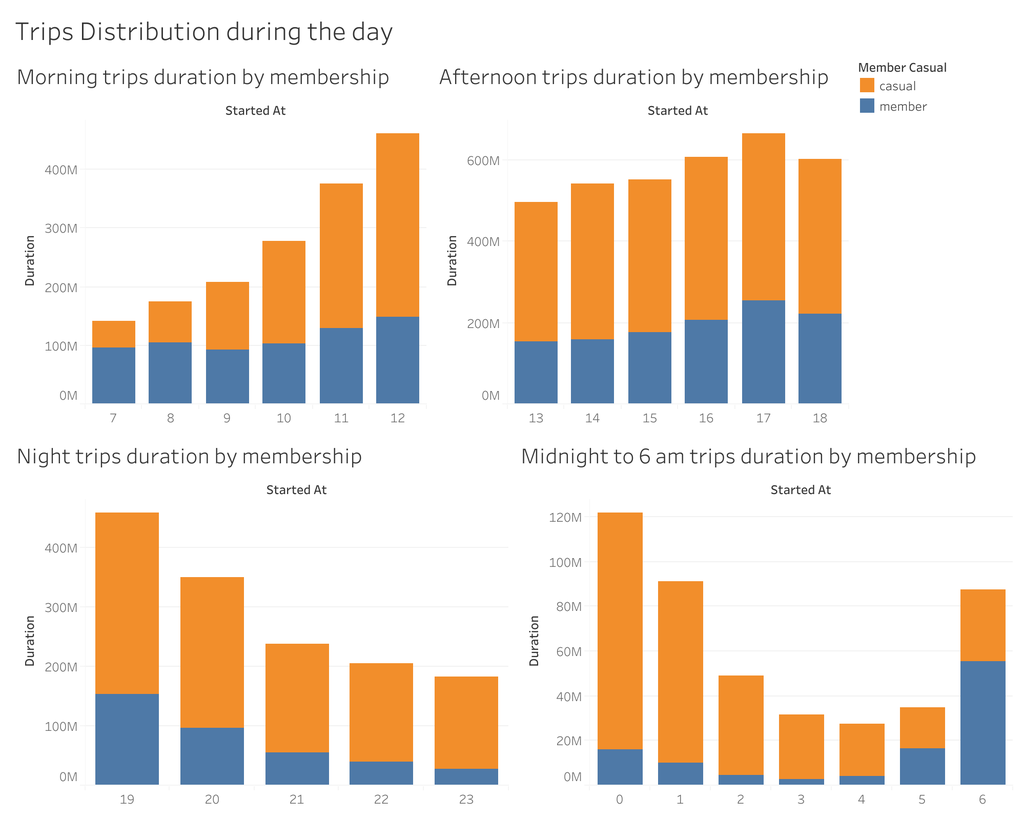